# Working with Data Assignment 1

Kate Byrne

31 October 2018

### Setup

Required R libraries are below

```r
library(devtools)
library(readr)
library(ggplot2)
library(ggmap)
devtools::install_github('hadley/ggplot2')
devtools::install_github('dkahle/ggmap')
#library(rnoaa)
library(httr)
library(plyr)
library(jsonlite)
library(dplyr)
library(readODS)
library(knitr)
library(hms)
library(lubridate)
library(tidyr)
library(stringi)
```

## Task 1: Quarterly Economic Indicators

### 1.1 Dublin Employment Trends

Below is the plot of quarterly Dublin Employment Trends for the period 2006 - 2016.

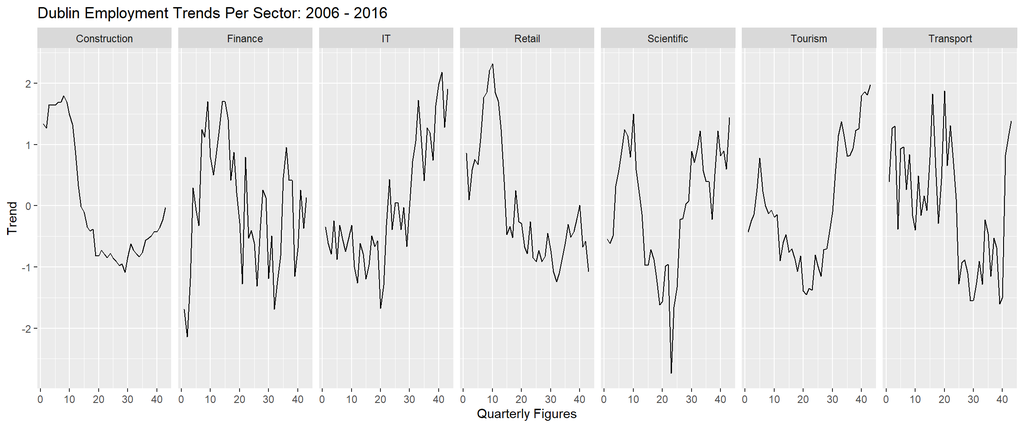

```r
employ.read <- read_delim('dublin employment trends.txt', ':')
qplot(data = employ.read , x = Time , y = Employment, geom = 'line', xlab = 'Quarterly Figures', ylab = 'Trend', main = 'Dublin Employment Trends Per Sector: 2006 - 2016') + facet_grid ( .~ Sector)
```

From the graph above, and the table of maximum and minimum values below, it appears that construction, finance, retail and transport all largely follow the same pattern of peaking in the earlier time period (construction, finance and retail: late 2007/early 2008, transport, late 2010) and then decreasing.

There is a sharp decrease in both construction and retail, with a less sharp drop in both finance and transport. This would be influenced by the nature of these these industries. In both retail and construction, people are employed to directly provide a product for sale, if sales are down, staff are let go. As many staff in these industries can also be on unsecure contracts, this can happen quite quickly. While the volumes of business and profits generated by both the finance and transport sectors was affected by the economic downturn (less people in work would mean less people getting peak time transport, less mortgages and loans were processed in the financial sector), a lot of their services are required regardless of economic factors (regular transportation, maintaining accounts and processing transactions), so while profits may have been down, the number of people employed could not decrease as quickly. Also, people in these industries can have more secure employment contracts so lay-offs might not happen as quickly.

Of these industries, some either appear to recover fully (transport) or partially (finance, construction). However, retail seems to be contuining an overall downward trajectory. While all sectors would have been affected by the downturn in the economy, there was a 5-fold increase in online shopping in Ireland between 2007 and 2017 [1], which would affect the recovery of high street retail. Also, since many of the large online retailers are not based in Ireland (e.g. ASOS and Amazon are UK based), the shift to online shopping would further reduce the numbers of people employed in retail in Dublin and Ireland.

Employment in IT have been increasing steadily since the end of 2010. This has been a growing industry in Ireland, and specifically Dublin due to the arrival of several international Tech companies such as AirBnb (2013) and Facebook (2008).

As the number of tourists coming to Ireland and Dublin has increased in recent years [2], you would expect that the number of people employed in the tourism sector has increased. Since the recession between 2007 and 2009 was a global recession, you would expect the number of tourists coming to Ireland in this period would have been impacted.

As employment in the scientific sector largely depends on government and indystry sponsorship and grants which are often for a fixed period of time such as 3-5 years, we can see why the time period immediately after the recession had the lowest rates, if less new grants were awarded during the recession period, this would impact the number of people employed in the following years.

Below are the dates for minumum and maximum employment values for each sector. Finance has three quarters with the same maximum.

```r
min.employ <- employ.read %>% group_by(Sector) %>% filter(., Employment == min(Employment))
max.employ <- employ.read %>% group_by(Sector) %>% filter(., Employment == max(Employment))
employ.extreme <- left_join(min.employ, max.employ, by = 'Sector', suffix = c('.min', '.max'))[c('Sector', 'QuarterYear.min', 'Employment.min', 'Time.min', 'QuarterYear.max', 'Employment.max', 'Time.max')]
employ.extreme <- employ.extreme %>% mutate(Employment.diff = Employment.max-Employment.min)
kable(employ.extreme, digits = 2)
```

| Sector | QuarterYear.min | Employment.min | Time.min | QuarterYear.max | Employment.max | Time.max | Employment.diff |
| --- | --- | --- | --- | --- | --- | --- | --- |
| Construction | 1’13 | -1.1 | 29 | 4’07 | 1.8 | 8 | 2.9 |
| Retail | 4’13 | -1.2 | 32 | 2’08 | 2.3 | 10 | 3.6 |
| Transport | 3’15 | -1.6 | 39 | 4’10 | 1.9 | 20 | 3.5 |
| Tourism | 1’11 | -1.4 | 21 | 3’16 | 2.0 | 43 | 3.4 |
| IT | 4’10 | -1.7 | 20 | 1’16 | 2.2 | 41 | 3.9 |
| Scientific | 3’11 | -2.7 | 23 | 2’08 | 1.5 | 10 | 4.2 |
| Finance | 2’06 | -2.1 | 2 | 1’08 | 1.7 | 9 | 3.8 |
| Finance | 2’06 | -2.1 | 2 | 2’09 | 1.7 | 14 | 3.8 |
| Finance | 2’06 | -2.1 | 2 | 3’09 | 1.7 | 15 | 3.8 |

### 1.2 Dublin Property Trends

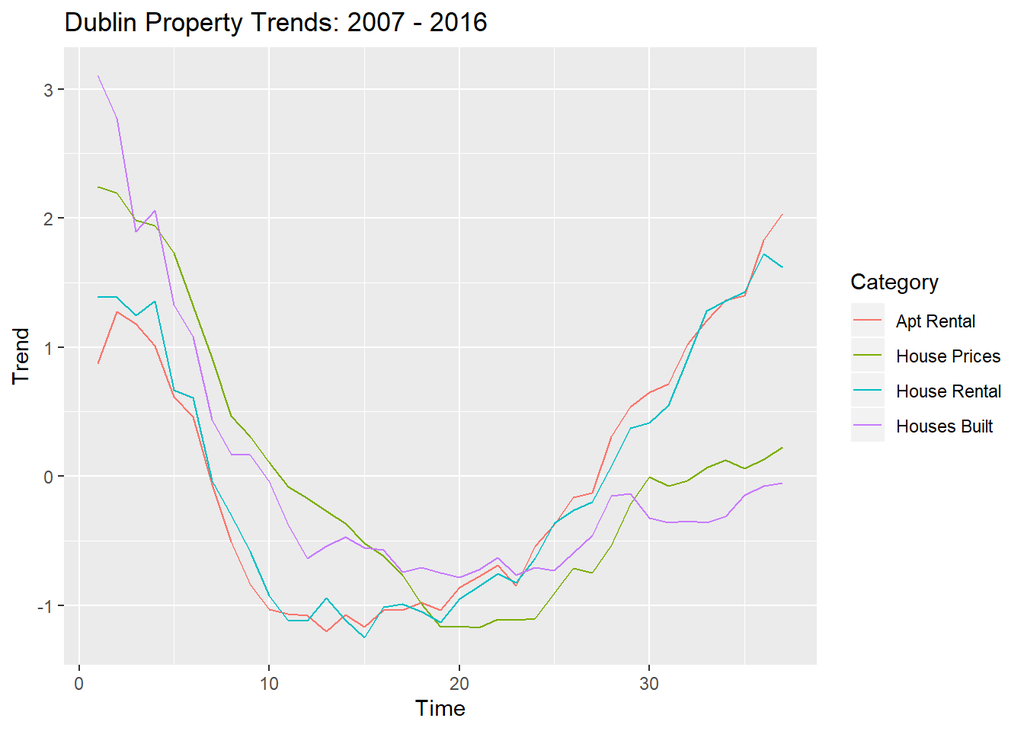

```r
prop.read <- read_tsv('dublin property trends.txt')
qplot(data = prop.read , x = Time , y = Trend, geom = 'line', colour = Category, xlab = 'Time', ylab = 'Trend', main = 'Dublin Property Trends: 2007 - 2016')
```

```r
prop.split <- split(prop.read, prop.read$Category)
prop.apt.rent <- select(prop.split[[1]], Time, Year, Trend, Category)
prop.house.price <- select(prop.split[[2]], Time, Year, Trend, Category)
prop.house.rent <- select(prop.split[[3]], Time, Year, Trend, Category)
prop.house.built <- select(prop.split[[4]], Time, Year, Trend, Category)

prop.cols <- prop.apt.rent %>% left_join(prop.house.price, by = c('Time', 'Year'), suffix = c('.apt.rent', '.house.price')) %>% left_join( prop.house.built, by = c('Time', 'Year'), suffix = c('.', '.house.built')) %>% left_join(., prop.house.rent, by = c('Time', 'Year'), suffix = c('.', '.house.rent'))

prop.filter.buy <- filter(prop.cols, (Trend.house.price > Trend.house.rent & Trend.house.price > Trend.apt.rent & Trend. > Trend.house.rent & Trend. > Trend.apt.rent))
prop.filter.rent <- filter(prop.cols, (Trend.house.price < Trend.house.rent & Trend.house.price < Trend.apt.rent & Trend. < Trend.house.rent & Trend. < Trend.apt.rent))
```

The timeperiod in this dataset is from Q3 07 to Q3 16. Over this time, the balance of rent vs buy has changed in Dublin. For the time period Q3 07 to Q3 11, both house prices and houses built outstripped both houses and apartments rented. For the time period Q2 13 to Q3 16, the situation is reversed and both house and apartment rental outstripped house prices and house buying.

Comparing this data to the construction employment figures in the previous question, we can see that the number of houses built and house prices behave in a similar pattern to the construction employment figures. The highest rates for house prices, houses built and construction jobs are at Q3 2007, Q3 2007 and Q4 2007 respectively. It should be noted that this is at the start of the dataset for house prices and houses being built so there may have been higher rates before this. The construction employmant data started in Q1 2006 so we can say that Q4 2007 is the local maximum rate. Similarly, the lowest rates for house prices, houses built and construction jobs are Q3 2012, Q2 2012 and Q1 2013 repectively.

```r
min.prop <- prop.read %>% group_by(Category) %>% filter(., Trend == min(Trend))
max.prop <- prop.read %>% group_by(Category) %>% filter(., Trend == max(Trend))
prop.extreme <- left_join(min.prop, max.prop, by = 'Category', suffix = c('.min', '.max'))[c('Category', 'Year.min', 'Trend.min', 'Time.min', 'Year.max', 'Trend.max', 'Time.max')]
prop.extreme <- prop.extreme %>% mutate(Trend.diff = Trend.max-Trend.min)
employ.extreme.con <- employ.extreme %>% filter(., Sector == 'Construction') %>% setNames(c('Category', 'Year.min', 'Trend.min', 'Time.min', 'Year.max',  'Trend.max', 'Time.max', 'Trend.diff'))
kable(bind_rows(prop.extreme, employ.extreme.con), digits = 2)
```

| Category | Year.min | Trend.min | Time.min | Year.max | Trend.max | Time.max | Trend.diff |
| --- | --- | --- | --- | --- | --- | --- | --- |
| Houses Built | Q2 12 | -0.78 | 20 | Q3 07 | 3.1 | 1 | 3.9 |
| House Prices | Q3 12 | -1.17 | 21 | Q3 07 | 2.2 | 1 | 3.4 |
| House Rental | Q1 11 | -1.25 | 15 | Q2 16 | 1.7 | 36 | 3.0 |
| Apt Rental | Q3 10 | -1.20 | 13 | Q3 16 | 2.0 | 37 | 3.2 |
| Construction | 1’13 | -1.09 | 29 | 4’07 | 1.8 | 8 | 2.9 |

## Task 2: Real Time Bike Info

### 2.1 Summarise information available

```r
stations <- GET('https://api.jcdecaux.com/vls/v1/stations?apiKey=174980a157364085f718726daecb380b7aeaf5b4')
http_type(stations)
```

```
## [1] "application/json"
```

```r
stations.df <- jsonlite::fromJSON(content(stations, 'text'), simplifyVector = TRUE)
#count(stations.df, vars = 'contract_name')
```

As Dublin has quite a high number of stations and I’m most familiar with Dublin, I’ll choose that.

```r
bike <- GET('https://api.jcdecaux.com/vls/v1/stations?contract=Dublin&apiKey=174980a157364085f718726daecb380b7aeaf5b4')
http_type(bike)
```

```
## [1] "application/json"
```

```r
bike.df <- jsonlite::fromJSON(content(bike, 'text'), simplifyVector = TRUE)
```

```r
sum.bike <- summary(bike.df)
```

The number of available bikes and available bike stands are also available

```r
#filter(bike.df, banking==FALSE)
#bike.df[bike.df$banking==F]

#bike.df[bike.df$address=='Smithfield North']

#bike.df$address=='Smithfield North'

#bike.df$banking
```

```r
bike.df <- bike.df[order(bike.df$number),]
#bike.df
```

```r
str(bike.df)
```

```
## 'data.frame':    114 obs. of  12 variables:
##  $ number               : int  1 2 3 4 5 6 7 8 9 10 ...
##  $ contract_name        : chr  "Dublin" "Dublin" "Dublin" "Dublin" ...
##  $ name                 : chr  "CLARENDON ROW" "BLESSINGTON STREET" "BOLTON STREET" "GREEK STREET" ...
##  $ address              : chr  "Clarendon Row" "Blessington Street" "Bolton Street" "Greek Street" ...
##  $ position             :'data.frame':   114 obs. of  2 variables:
##   ..$ lat: num  53.3 53.4 53.4 53.3 53.3 ...
##   ..$ lng: num  -6.26 -6.27 -6.27 -6.27 -6.26 ...
##  $ banking              : logi  FALSE TRUE FALSE FALSE FALSE FALSE ...
##  $ bonus                : logi  FALSE FALSE FALSE FALSE FALSE FALSE ...
##  $ bike_stands          : int  31 20 20 20 40 20 29 30 24 16 ...
##  $ available_bike_stands: int  31 18 20 19 25 13 27 29 24 3 ...
##  $ available_bikes      : int  0 2 0 1 15 7 2 1 0 13 ...
##  $ status               : chr  "OPEN" "OPEN" "OPEN" "OPEN" ...
##  $ last_update          : num  1.54e+12 1.54e+12 1.54e+12 1.54e+12 1.54e+12 ...
```

```r
bike.df
```

```
##     number contract_name                              name
## 17       1        Dublin                     CLARENDON ROW
## 82       2        Dublin                BLESSINGTON STREET
## 103      3        Dublin                     BOLTON STREET
## 44       4        Dublin                      GREEK STREET
## 39       5        Dublin                  CHARLEMONT PLACE
## 6        6        Dublin                CHRISTCHURCH PLACE
## 47       7        Dublin                       HIGH STREET
## 58       8        Dublin                 CUSTOM HOUSE QUAY
## 35       9        Dublin                  EXCHEQUER STREET
## 90      10        Dublin                       DAME STREET
## 26      11        Dublin                 EARLSFORT TERRACE
## 79      12        Dublin                     ECCLES STREET
## 11      13        Dublin           FITZWILLIAM SQUARE WEST
## 16      14        Dublin               FOWNES STREET UPPER
```

[output cut: 445 more lines]

### 2.2 Plot Dublin Bikes Data

If someone quickly needed to get a Dublin bike, but didn’t have a Dublin bike card already set up, they would need a bike station with payment facilities. Below is a plot of the number of available bikes by station and whether the bike station takes payment.

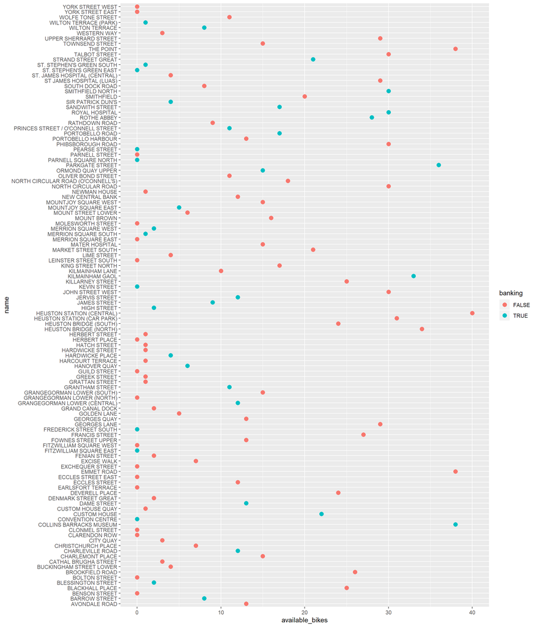

```r
qplot(available_bikes, name, data = bike.df , colour = banking, size=I(3))
```

## Task 3 Dublin Bus

### 3.1 Shaping and describing the data

```r
unzip('DublinBus.zip')
trips.df <- read_csv('googletransitdublinbusp20130315-1546\\trips.txt')
routes.df <- read_csv('googletransitdublinbusp20130315-1546\\routes.txt')
calendar.df <- read_csv('googletransitdublinbusp20130315-1546\\calendar.txt')
calendar_dates.df <- read_csv('googletransitdublinbusp20130315-1546\\calendar_dates.txt')
shapes.df <- read_csv('googletransitdublinbusp20130315-1546\\shapes.txt')
stops.df <- read_csv('googletransitdublinbusp20130315-1546\\stops.txt')
transfers.df <- read_csv('googletransitdublinbusp20130315-1546\\transfers.txt')
agency.df <- read_csv('googletransitdublinbusp20130315-1546\\agency.txt')
stop_times.df <- read_csv('googletransitdublinbusp20130315-1546\\stop_times.txt')
```

There are 119 unique routes in this dataset, all of which are route type 3, ‘Bus. Used for short- and long-distance bus routes.’ [1]. There was a total of 16846 different possible trips. The number of daily journeys for each route, split out by service type (weekdays, Saturdays and Sunday/Bank Holiday) are shown in Figure X below.

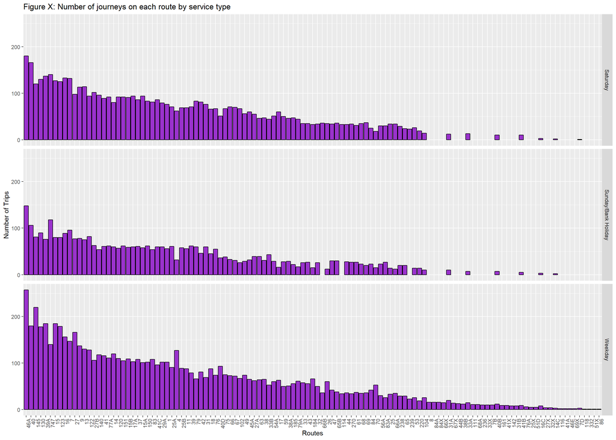

```r
route.num.trip <- left_join(trips.df, routes.df, by = 'route_id') %>% mutate(Service=case_when(service_id == 2 ~ 'Sunday/Bank Holiday', service_id == 1 ~ 'Weekday',  service_id == 3 ~ 'Saturday')) %>% select(Service, route_short_name, trip_id) %>% count(., Service, route_short_name)

ggplot(data=route.num.trip, aes(x=reorder(route_short_name, -n), y=n)) + facet_grid(rows=vars(Service), scale = 'fixed') + geom_histogram(stat = 'identity', fill='darkorchid3', colour='black') + theme(axis.text.x = element_text(angle = 90, hjust = 1)) + labs(x = 'Routes', y = 'Number of Trips', title='Figure X: Number of journeys on each route by service type')
```

```r
#common join used at multiple points in the code
bus.join <- left_join(routes.df, trips.df, by='route_id') %>% left_join(., stop_times.df, by='trip_id') %>% left_join(., stops.df, by='stop_id') %>% mutate(Service=case_when(service_id == 2 ~ 'Sunday/Bank Holiday', service_id == 1 ~ 'Weekday',  service_id == 3 ~ 'Saturday'))

#calculating the unit of distance in the dataset
dist.calc <- bus.join %>% filter(route_short_name == 16) %>% filter(trip_id == min(trip_id)) %>% filter(stop_name == 'Redmond\'s Hill') %>% select(shape_dist_traveled) - bus.join %>% filter(route_short_name == 16) %>% filter(trip_id == min(trip_id)) %>% filter(stop_name == 'George\'s St') %>% select(shape_dist_traveled)

#calculating the route lengths
route.length <- bus.join %>% group_by(route_short_name, route_long_name, trip_id) %>% summarise(Dist.all = max(shape_dist_traveled)) %>% ungroup() %>% group_by(route_short_name, route_long_name) %>% summarise(Dist.mean = mean(Dist.all)/1000) %>% ungroup()

# base df that most and least frequent routes and mean length is based on
bus.freq <- bus.join %>% group_by(route_short_name, service_id,direction_id) %>% filter(., stop_sequence==1) %>% select(., route_short_name, route_long_name, Service, direction_id, arrival_time, stop_sequence) %>% arrange(., route_short_name, Service, direction_id, arrival_time) %>% mutate(., Freq = difftime(arrival_time,lag(arrival_time),units='mins')) %>% na.omit() %>% filter(Freq>0)  %>% ungroup() %>% select(route_short_name, route_long_name, Service, Freq) %>% group_by(Service)

freq.mean <- bus.freq %>% summarise(Freq=mean(Freq))

most.freq <- bus.freq %>% filter(Freq==min(Freq)) %>% distinct() %>% mutate(Classification='Most Fequent') %>% ungroup()
leastfreq <- bus.freq %>% filter(Freq==max(Freq)) %>% distinct() %>% mutate(Classification='Least Fequent') %>% ungroup()

extreme.freq <- rbind(most.freq, leastfreq) %>% select(Service, Classification, Freq, Route=route_short_name, Route.name=route_long_name) %>% arrange(., Service, Freq)
```

The mean frequencies across all routes for each type of service are as follows: Saturday: 30.48 mins, Sunday/Bank Holiday: 37.52 mins and Weekday: 26.25 mins. The routes with the highest and lowest frequencies routes for each type of service, along with their frequency in minutes are shown in the table below.

```r
kable(extreme.freq)
```

| Service | Classification | Freq | Route | Route.name |
| --- | --- | --- | --- | --- |
| Saturday | Most Fequent | 5 mins | 102 | Bus Interchange - DART Station |
| Saturday | Least Fequent | 345 mins | 40B | River Meade Avenue - Cumberland Street |
| Sunday/Bank Holiday | Most Fequent | 5 mins | 40 | Liffey Valley Shop Cen - Seamus Ennis Rd |
| Sunday/Bank Holiday | Least Fequent | 415 mins | 41B | Cemetery - Irish Life Mall |
| Weekday | Most Fequent | 1 mins | 46A | Train Station - Phoenix Pk Gate |
| Weekday | Least Fequent | 850 mins | 16C | Stone Masons Way - St. Martin’s Chapel |

```r
##trying to figure out first and last bus - getting bogged down
#bus.join %>% mutate(Service=case_when(service_id == 2 ~ 'Sunday/Bank Holiday', service_id == 1 ~ 'Weekday',  service_id == 3 #~ 'Saturday')) %>% select(Service, route_short_name, route_long_name, arrival_time) %>% #mutate(actual.time=case_when(arrival_time < as.hms('04:00:00') ~ arrival_time+as.hms('24:00:00')))  %>% #filter(route_short_name == 41, Service=='Sunday/Bank Holiday') %>% arrange(arrival_time)

#library(hms)
#typeof(as.hms('04:00:00'))

#%>% group_by(Service) %>% filter(arrival_time==min(arrival_time, na.rm=TRUE) | arrival_time==max(arrival_time, na.rm=TRUE)) %>% select(Service, route_short_name, route_long_name, arrival_time)

#bus.join %>% mutate(Service=case_when(service_id == 2 ~ 'Sunday/Bank Holiday', service_id == 1 ~ 'Weekday',  service_id == 3 ~ 'Saturday'))  %>% filter(route_short_name == 41) %>% select(Service, route_short_name, service_id, arrival_time, departure_time)  %>% distinct() %>% arrange(arrival_time)
```

The route map is shown below in Figure X, overlaid over a map of Dublin. The longest and shortest routes are shown.

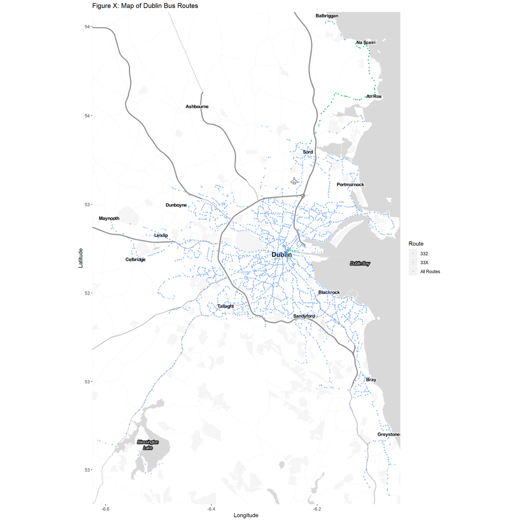

```r
lat.long.all <- select(stops.df, Latitude=stop_lat, Longitude=stop_lon) %>% mutate(., Route='All Routes') %>% select(Route, Longitude, Latitude) %>% distinct()

lat.long.longest <- filter(bus.join, route_short_name==filter(route.length, Dist.mean==max(Dist.mean))$route_short_name) %>% select(., Route=route_short_name, Longitude=stop_lon, Latitude=stop_lat) %>% distinct()

lat.long.shortest <- filter(bus.join, route_short_name==filter(route.length, Dist.mean==min(Dist.mean))$route_short_name) %>% select(., Route=route_short_name, Longitude=stop_lon, Latitude=stop_lat) %>% distinct()

lat.long.combo <- rbind(lat.long.all, lat.long.longest, lat.long.shortest)

# store bounding box coordinates - add a small amount so box extends slightly beyond the furthermost stop
dublin_bb <- c(left = (min(stops.df$stop_lon) - 0.01),
            bottom = (min(stops.df$stop_lat) - 0.01),
            right = (max(stops.df$stop_lon) + 0.01),
            top = (max(stops.df$stop_lat) + 0.01))

dublin_stamen <- get_stamenmap(bbox = dublin_bb, zoom = 11,  maptype = 'toner-lite')

ggmap(dublin_stamen, legend = 'right') + geom_point(data = lat.long.combo, mapping = aes(x = Longitude, y = Latitude, na.rm=TRUE, colour = Route), size = 0.6, alpha = .5) +ggtitle('Figure X: Map of Dublin Bus Routes') + labs(x='Longitude', y='Latitude')
```

The units of distance travelled are not specified in the dataset. The distance on the 16 route from the George’s Street stop to the Redmond’s Hill stop is given in the dataset is 491.34. The distance between these two stops according to Google maps is 500m, so it appears that the unit of distance is meters. The mean and median route length are very similar at 19.68 km and 19.84 km respectively. The shortest route is Route 332, Donabate Station - Opposite the Burrow Estate, at 4 km. The longest route is Route 33X, Barnageeragh Road - Huguenot Cemetery, at 43.75 km. Both can ben seen in Figure X above.

### Pick a route

```r
home.route <- 49
bus.home <- bus.join %>% filter(route_short_name==home.route, Service=='Weekday')
```

I live in Harold’s Cross and work in College Green so am picking Route 49, Cloonmore Drive - Grand Canal Quay. According to the data, direction_id = 1 is in the direction of Pearse St, so that’s the direction I would get to work. Direction_id = 0 is in the direction of The Square, so that would be the direction I would get home from work. The stops in question are listed below.

```r
home.stops <- bus.home %>%  filter(stop_id=='8220DB001296' | stop_id == '8220DB004521' | stop_id=='8220DB001339' | stop_id=='8220DB005192')
kable(home.stops %>% select(route_short_name, route_long_name, direction_id, stop_headsign, stop_id, stop_name) %>% distinct() )
```

| route_short_name | route_long_name | direction_id | stop_headsign | stop_id | stop_name |
| --- | --- | --- | --- | --- | --- |
| 49 | Cloonmore Drive - Grand Canal Quay | 0 | The Square | 8220DB004521 | College Green |
| 49 | Cloonmore Drive - Grand Canal Quay | 0 | The Square | 8220DB001296 | Harold’s Cross Rd |
| 49 | Cloonmore Drive - Grand Canal Quay | 1 | Pearse St | 8220DB001339 | Harold’s Cross Rd |
| 49 | Cloonmore Drive - Grand Canal Quay | 1 | Pearse St | 8220DB005192 | Fleet Street |

```r
commute.trips <- home.stops %>% filter((direction_id==1 & stop_id=='8220DB005192' & arrival_time>as.hms('08:15:00') & arrival_time<as.hms('09:00:00')) | (direction_id==0 & stop_id=='8220DB004521' & arrival_time>as.hms('17:00:00') & arrival_time<as.hms('17:45:00'))) %>% select(trip_id)

length.route <- home.stops %>% inner_join(commute.trips, by='trip_id') %>% arrange(trip_id, stop_sequence) %>% group_by(direction_id, trip_id) %>% mutate(length.time=(lead(arrival_time) - arrival_time)/60) %>% mutate(length.dist=(lead(shape_dist_traveled) - shape_dist_traveled)/1000) %>% ungroup() %>% select(direction_id, stop_headsign, length.time, length.dist) %>% filter(!is.na(length.dist)) %>% distinct()
```

The trip into work should take 26.58 mins and 4.31 km. The trip home from work should take 24.35 mins and 4 km. Neither of these times appear to take into consideration traffic though.

If I needed to arrive for work at between 8.15 and 9am, and want to get a bus home from work between 5pm and 5.45 pm, I’ll have to get one of the services below.

```r
kable(inner_join(home.stops, commute.trips, by='trip_id') %>% mutate(Journey=case_when(stop_headsign=='Pearse St' ~ 'Commute to work', stop_headsign=='The Square' ~ 'Commute to home') ) %>% select(Service, Journey, Direction=stop_headsign, stop_name, arrival_time))
```

| Service | Journey | Direction | stop_name | arrival_time |
| --- | --- | --- | --- | --- |
| Weekday | Commute to home | The Square | College Green | 17:06:41 |
| Weekday | Commute to home | The Square | Harold’s Cross Rd | 17:31:02 |
| Weekday | Commute to home | The Square | College Green | 17:21:41 |
| Weekday | Commute to home | The Square | Harold’s Cross Rd | 17:46:02 |
| Weekday | Commute to home | The Square | College Green | 17:36:41 |
| Weekday | Commute to home | The Square | Harold’s Cross Rd | 18:01:02 |
| Weekday | Commute to work | Pearse St | Harold’s Cross Rd | 08:29:13 |
| Weekday | Commute to work | Pearse St | Fleet Street | 08:55:48 |

The times for the earliest and latest busses on Route 49 are below.

```r
kable(bus.join %>% group_by(Service, stop_headsign) %>% filter(!is.na(arrival_time), route_short_name==home.route) %>% summarise(earliest.bus=min(arrival_time), latest.bus= max(arrival_time)))
```

| Service | stop_headsign | earliest.bus | latest.bus |
| --- | --- | --- | --- |
| Saturday | Pearse St | 06:45:00 | 23:58:51 |
| Saturday | The Square | 06:45:00 | 23:58:00 |
| Sunday/Bank Holiday | Pearse St | 09:30:00 | 23:58:00 |
| Sunday/Bank Holiday | The Square | 10:30:00 | 23:59:36 |
| Weekday | Pearse St | 06:15:00 | 23:59:34 |
| Weekday | The Square | 06:10:00 | 23:59:00 |

I like exploring Dublin on a Saturday but I don’t have a car and I don’t like walking between stops to change bus. Here I’ll look at everywhere that I can get to, using busses that interconnect with my chosen route 49. This analysis can easily be changed to look at other routes by changing the bus route chosen above.

```r
bus.join.sat <- filter(bus.join, Service=='Saturday')
stops.home <- bus.join.sat %>% filter(route_short_name==home.route)

stops.intersect <- inner_join(stops.home, bus.join.sat, by='stop_id', suffix=c('.home', '.intersect')) %>% select(route_short_name.intersect) %>% distinct() %>% inner_join(bus.join.sat, by = c("route_short_name.intersect" = "route_short_name")) %>% select(Longitude=stop_lon, Latitude=stop_lat) %>% distinct()

intersect.routes <- rbind((stops.intersect %>% mutate(Route=paste('All Routes Intersecting with Route', home.route))), (stops.home %>% select(Longitude=stop_lon, Latitude=stop_lat) %>% mutate(Route=paste('Route', home.route)))) %>% select(Route, Longitude, Latitude)
```

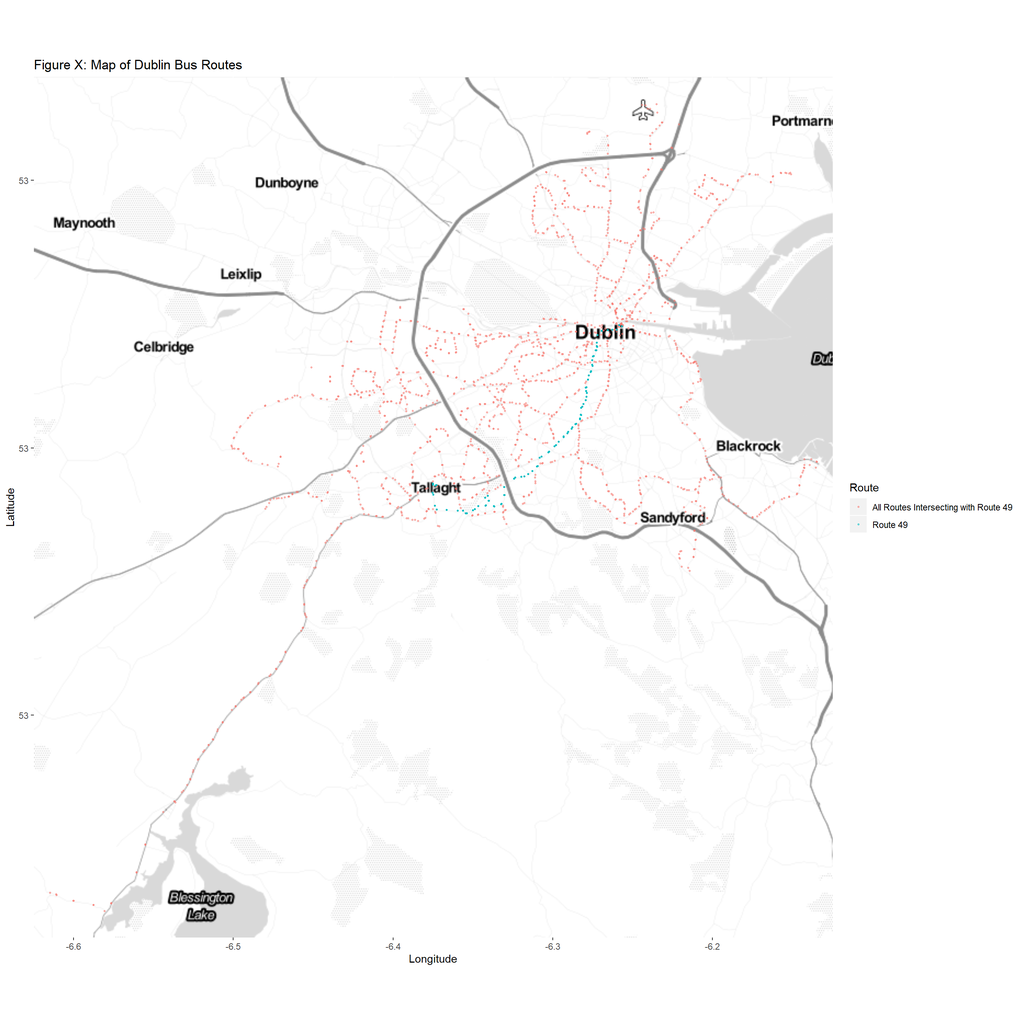

```r
# store bounding box coordinates - add a small amount so box extends slightly beyond the furthermost stop
dublin_intersect_bb <- c(left = (min(stops.intersect$Longitude) - 0.01),
            bottom = (min(stops.intersect$Latitude) - 0.01),
            right = (max(stops.intersect$Longitude) + 0.01),
            top = (max(stops.intersect$Latitude) + 0.01))

dublin_intersect_stamen <- get_stamenmap(bbox = dublin_intersect_bb, zoom = 11,  maptype = 'toner-lite')

ggmap(dublin_intersect_stamen, legend = 'right') + geom_point(data = intersect.routes, mapping = aes(x = Longitude, y = Latitude, na.rm=TRUE, colour = Route), size = 0.6, alpha = .5) +ggtitle('Figure X: Map of Dublin Bus Routes') + labs(x='Longitude', y='Latitude')
```

# Task 4

```r
#loading in the footfall data
url.footfall <- 'https://data.smartdublin.ie/dataset/8204be0a-6348-459e-96e9-65bb75600ec3/resource/384fe47a-2f25-4f52-8fc5-8e61899951e9/download/pedestrianfootfall2013.ods'
download.file(url.footfall, 'footfall_ods.ods')
sheet.names <- ods_sheets('pedestrianfootfall2013.ods')
```

```r
#getting list of camera locations
camera.locations <- read_ods('pedestrianfootfall2013.ods',sheet.names[1])[1]
colnames(camera.locations) <- c('Loc')
camera.locations %>% filter(., grepl("Entrance Name:", Loc, fixed = TRUE))
```

```
##                                          Loc
## 1  Entrance Name: O'Connell Street at Clerys
## 2               Entrance Name: South King St
## 3         Entrance Name: South Great Georges
## 4                   Entrance Name: Talbot St
## 5                     Entrance Name: Mary St
## 6                    Entrance Name: Moore St
## 7          Entrance Name: Capel St at Mullen
## 8  Entrance Name: Grafton St at Card Gallery
## 9           Entrance Name: Grafton St at M&S
## 10 Entrance Name: O'Connell Street at Easons
## 11    Entrance Name: Henry Street at Butlers
## 12       Entrance Name: Grafton St at Korkys
## 13           Entrance Name: South William St
```

```r
sheet.names
```

```
##  [1] "Week_1"  "Week_2"  "Week_3"  "Week_4"  "Week_5"  "Week_6"  "Week_7"
##  [8] "Week_8"  "Week_9"  "Week_10" "Week_11" "Week_12" "Sheet13" "Week_14"
## [15] "Week_15" "Week_16" "Week_17" "Week_18" "Week_19" "Week_20" "Week_21"
## [22] "Week_22" "Week_23" "Week_24" "Week_25" "Week_26" "Week_27" "Week_28"
## [29] "Week_29" "Week_30" "Week_31" "Week_32" "Week_33" "Week_34" "Week_35"
## [36] "Week_36" "Week_37" "Week_38" "Week_39" "Week_40" "Week_41" "Week_42"
## [43] "Week_43" "Week_44" "Week_45" "Week_46" "Week_47" "Week_48" "Week_49"
## [50] "Week_50" "Week_51" "Week_52"
```

```r
#
camera1.name <- 'Entrance Name: Capel St at Mullen'
camera2.name <- 'Entrance Name: Grafton St at M&S'

camera1.all <- data.frame(matrix(ncol = 15, nrow = 0))
colnames(camera1.all) <- c('Time', 'Mon.In', 'Mon.Out', 'Tue.In', 'Tue.Out', 'Wed.In', 'Wed.Out', 'Thurs.In', 'Thurs.Out', 'Fri.In', 'Fri.Out', 'Sat.In', 'Sat.Out', 'Sun.In', 'Sun.Out')

camera2.all <- data.frame(matrix(ncol = 15, nrow = 0))
colnames(camera2.all) <- c('Time', 'Mon.In', 'Mon.Out', 'Tue.In', 'Tue.Out', 'Wed.In', 'Wed.Out', 'Thurs.In', 'Thurs.Out', 'Fri.In', 'Fri.Out', 'Sat.In', 'Sat.Out', 'Sun.In', 'Sun.Out')

for(week.i in 1:length(sheet.names))
{
  f1 <- read_ods('pedestrianfootfall2013.ods',sheet.names[week.i])

  if (ncol(f1)==15)
  {
    colnames(f1) <- c('Time', 'Mon.In', 'Mon.Out', 'Tue.In', 'Tue.Out', 'Wed.In', 'Wed.Out', 'Thurs.In', 'Thurs.Out', 'Fri.In', 'Fri.Out', 'Sat.In', 'Sat.Out', 'Sun.In', 'Sun.Out')
  } else {
    colnames(f1) <- c('Time', 'Mon.In', 'Mon.Out', 'Tue.In', 'Tue.Out', 'Wed.In', 'Wed.Out', 'Thurs.In', 'Thurs.Out', 'Fri.In', 'Fri.Out', 'Sat.In', 'Sat.Out', 'Sun.In', 'Sun.Out', 'unknown1', 'unknown2', 'unknown3')
  }
  f1 <- select(f1, Time, Mon.In, Mon.Out, Tue.In, Tue.Out, Wed.In, Wed.Out, Thurs.In, Thurs.Out, Fri.In, Fri.Out, Sat.In, Sat.Out, Sun.In, Sun.Out)

  camera1.row <- which(grepl(camera1.name, f1$Time))
  camera2.row <- which(grepl(camera2.name, f1$Time))

  camera1.slice <- slice(f1, (camera1.row+3):(camera1.row+26)) %>% mutate(Week=sheet.names[week.i])
  camera2.slice <- slice(f1, (camera2.row+3):(camera2.row+26)) %>% mutate(Week=sheet.names[week.i])

  camera1.all <- rbind(camera1.all, camera1.slice)
  camera2.all <- rbind(camera2.all, camera2.slice)

  f1 <- NULL
}
```

```r
#all fields are character (they contained some text before using split), so must change all numeric characters to numeric
camera1.all$Mon.In <- as.numeric(camera1.all$Mon.In)
camera1.all$Mon.Out <- as.numeric(camera1.all$Mon.Out)
camera1.all$Tue.In <- as.numeric(camera1.all$Tue.In)
camera1.all$Tue.Out <- as.numeric(camera1.all$Tue.Out)
camera1.all$Wed.In <- as.numeric(camera1.all$Wed.In)
camera1.all$Wed.Out <- as.numeric(camera1.all$Wed.Out)
camera1.all$Thurs.In <- as.numeric(camera1.all$Thurs.In)
camera1.all$Thurs.Out <- as.numeric(camera1.all$Thurs.Out)
camera1.all$Fri.In <- as.numeric(camera1.all$Fri.In)
camera1.all$Fri.Out <- as.numeric(camera1.all$Fri.Out)
camera1.all$Sat.In <- as.numeric(camera1.all$Sat.In)
camera1.all$Sat.Out <- as.numeric(camera1.all$Sat.Out)
camera1.all$Sun.In <- as.numeric(camera1.all$Sun.In)
camera1.all$Sun.Out <- as.numeric(camera1.all$Sun.Out)

camera2.all$Mon.In <- as.numeric(camera2.all$Mon.In)
camera2.all$Mon.Out <- as.numeric(camera2.all$Mon.Out)
camera2.all$Tue.In <- as.numeric(camera2.all$Tue.In)
camera2.all$Tue.Out <- as.numeric(camera2.all$Tue.Out)
camera2.all$Wed.In <- as.numeric(camera2.all$Wed.In)
camera2.all$Wed.Out <- as.numeric(camera2.all$Wed.Out)
camera2.all$Thurs.In <- as.numeric(camera2.all$Thurs.In)
camera2.all$Thurs.Out <- as.numeric(camera2.all$Thurs.Out)
camera2.all$Fri.In <- as.numeric(camera2.all$Fri.In)
camera2.all$Fri.Out <- as.numeric(camera2.all$Fri.Out)
camera2.all$Sat.In <- as.numeric(camera2.all$Sat.In)
camera2.all$Sat.Out <- as.numeric(camera2.all$Sat.Out)
camera2.all$Sun.In <- as.numeric(camera2.all$Sun.In)
camera2.all$Sun.Out <- as.numeric(camera2.all$Sun.Out)

# there was inconsistency in sheet naming so fixing this
camera1.all$Week <- gsub('Sheet13', 'Week_13', camera1.all$Week)
camera2.all$Week <- gsub('Sheet13', 'Week_13', camera2.all$Week)

camera1.all$Week <- gsub('Week_1\\>', 'Week_01', camera1.all$Week)
camera1.all$Week <- gsub('Week_2\\>', 'Week_02', camera1.all$Week)
camera1.all$Week <- gsub('Week_3\\>', 'Week_03', camera1.all$Week)
camera1.all$Week <- gsub('Week_4\\>', 'Week_04', camera1.all$Week)
camera1.all$Week <- gsub('Week_5\\>', 'Week_05', camera1.all$Week)
camera1.all$Week <- gsub('Week_6\\>', 'Week_06', camera1.all$Week)
camera1.all$Week <- gsub('Week_7\\>', 'Week_07', camera1.all$Week)
camera1.all$Week <- gsub('Week_8\\>', 'Week_08', camera1.all$Week)
camera1.all$Week <- gsub('Week_9\\>', 'Week_09', camera1.all$Week)
camera2.all$Week <- gsub('Week_1\\>', 'Week_01', camera2.all$Week)
camera2.all$Week <- gsub('Week_2\\>', 'Week_02', camera2.all$Week)
camera2.all$Week <- gsub('Week_3\\>', 'Week_03', camera2.all$Week)
camera2.all$Week <- gsub('Week_4\\>', 'Week_04', camera2.all$Week)
camera2.all$Week <- gsub('Week_5\\>', 'Week_05', camera2.all$Week)
camera2.all$Week <- gsub('Week_6\\>', 'Week_06', camera2.all$Week)
camera2.all$Week <- gsub('Week_7\\>', 'Week_07', camera2.all$Week)
camera2.all$Week <- gsub('Week_8\\>', 'Week_08', camera2.all$Week)
camera2.all$Week <- gsub('Week_9\\>', 'Week_09', camera2.all$Week)

camera1.all
```

```
##       Time Mon.In Mon.Out Tue.In Tue.Out Wed.In Wed.Out Thurs.In Thurs.Out
## 1    00:00      0       0     35     106     19      37       34        30
## 2    01:00      0       0     42      78      4       7       10        11
## 3    02:00      0       0     37      78      6      12        2        14
## 4    03:00      0       0     28     145      2       1        5        10
## 5    04:00      0       0     24      75      4       5        3         6
## 6    05:00      0       0      9       7      8       6        9         5
## 7    06:00      0       0     30      14     18      11       15        19
## 8    07:00      0       0     21      21     57      29       65        34
## 9    08:00      0       0     16      20     86      61       80        75
## 10   09:00      0       0     21      14     86     100      122       113
## 11   10:00      0       0     35      33    146     172      124       178
## 12   11:00      0       0     78      78    225     259      251       280
## 13   12:00      0       0    105     109    333     363      356       390
## 14   13:00      0       0    148     147    460     395      455       466
```

[output cut: 2483 more lines]

```r
summary(camera1.all)
```

```
##      Time               Mon.In       Mon.Out        Tue.In
##  Length:1248        Min.   :  0   Min.   :  0   Min.   :   0
##  Class :character   1st Qu.: 20   1st Qu.: 22   1st Qu.:  20
##  Mode  :character   Median :111   Median : 99   Median : 128
##                     Mean   :152   Mean   :140   Mean   : 159
##                     3rd Qu.:272   3rd Qu.:250   3rd Qu.: 280
##                     Max.   :970   Max.   :569   Max.   :1080
##     Tue.Out        Wed.In        Wed.Out       Thurs.In     Thurs.Out
##  Min.   :  0   Min.   :   0   Min.   :  0   Min.   :  0   Min.   :  0
##  1st Qu.: 18   1st Qu.:  20   1st Qu.: 20   1st Qu.: 24   1st Qu.: 25
##  Median :110   Median : 129   Median :112   Median :144   Median :118
##  Mean   :147   Mean   : 160   Mean   :148   Mean   :168   Mean   :156
##  3rd Qu.:265   3rd Qu.: 274   3rd Qu.:263   3rd Qu.:284   3rd Qu.:277
##  Max.   :508   Max.   :1007   Max.   :509   Max.   :942   Max.   :518
##      Fri.In       Fri.Out        Sat.In        Sat.Out        Sun.In
##  Min.   :  0   Min.   :  0   Min.   :   0   Min.   :  0   Min.   :   0
##  1st Qu.: 25   1st Qu.: 32   1st Qu.:  28   1st Qu.: 45   1st Qu.:  21
##  Median :141   Median :130   Median : 128   Median :116   Median :  80
##  Mean   :173   Mean   :161   Mean   : 182   Mean   :169   Mean   : 123
##  3rd Qu.:290   3rd Qu.:279   3rd Qu.: 317   3rd Qu.:296   3rd Qu.: 207
##  Max.   :926   Max.   :482   Max.   :1374   Max.   :532   Max.   :1460
##     Sun.Out        Week
##  Min.   :  0   Length:1248
##  1st Qu.: 39   Class :character
##  Median : 78   Mode  :character
##  Mean   :115
##  3rd Qu.:183
##  Max.   :497
```

```r
summary(camera2.all)
```

```
##      Time               Mon.In        Mon.Out         Tue.In
##  Length:1248        Min.   :   0   Min.   :   0   Min.   :  42
##  Class :character   1st Qu.: 344   1st Qu.: 393   1st Qu.: 336
##  Mode  :character   Median :1132   Median :1321   Median :1315
##                     Mean   :1511   Mean   :1505   Mean   :1636
##                     3rd Qu.:2641   3rd Qu.:2588   3rd Qu.:2780
##                     Max.   :5251   Max.   :4928   Max.   :5670
##     Tue.Out         Wed.In        Wed.Out        Thurs.In
##  Min.   :  12   Min.   :   5   Min.   :  12   Min.   :   3
##  1st Qu.: 416   1st Qu.: 459   1st Qu.: 430   1st Qu.: 425
##  Median :1617   Median :1305   Median :1619   Median :1477
##  Mean   :1649   Mean   :1649   Mean   :1615   Mean   :1748
##  3rd Qu.:2745   3rd Qu.:2767   3rd Qu.:2688   3rd Qu.:2936
##  Max.   :5589   Max.   :5228   Max.   :4923   Max.   :5921
##    Thurs.Out        Fri.In        Fri.Out         Sat.In
##  Min.   :   6   Min.   :  44   Min.   :  30   Min.   :  46
##  1st Qu.: 488   1st Qu.: 520   1st Qu.: 556   1st Qu.: 784
##  Median :1800   Median :1530   Median :1762   Median :1435
##  Mean   :1742   Mean   :1769   Mean   :1758   Mean   :1701
##  3rd Qu.:2831   3rd Qu.:2851   3rd Qu.:2734   3rd Qu.:2492
##  Max.   :5816   Max.   :5431   Max.   :5375   Max.   :5370
##     Sat.Out         Sun.In        Sun.Out         Week
##  Min.   :  22   Min.   :   0   Min.   :   0   Length:1248
##  1st Qu.: 612   1st Qu.: 584   1st Qu.: 533   Class :character
##  Median :1566   Median :1087   Median : 987   Mode  :character
##  Mean   :1662   Mean   :1394   Mean   :1330
##  3rd Qu.:2368   3rd Qu.:2125   3rd Qu.:2074
##  Max.   :5540   Max.   :5338   Max.   :5243
```

```r
camera1.sum.week <- camera1.all %>% group_by(Week) %>% summarise_if(., is.numeric, sum)
camera2.sum.week <- camera2.all %>% group_by(Week) %>% summarise_if(., is.numeric, sum)
camera1.sum.week
```

```
## # A tibble: 52 x 15
##    Week  Mon.In Mon.Out Tue.In Tue.Out Wed.In Wed.Out Thurs.In Thurs.Out
##    <chr>  <dbl>   <dbl>  <dbl>   <dbl>  <dbl>   <dbl>    <dbl>     <dbl>
##  1 Week~      0       0   1815    1918   3606    3420     3836      3808
##  2 Week~   3081    2933   3310    3096   3432    3271     3183      3178
##  3 Week~   3170    2889   3353    3165   3113    3037     3356      3196
##  4 Week~   2905    2823   3066    2910   3289    3118     3558      3383
##  5 Week~   3071    2830   3265    3091   3238    3033     3262      3165
##  6 Week~   3251    3029   3069    3039   3582    3437     3159      3175
##  7 Week~   3345    3121   3471    3244   3693    3451     4253      3878
##  8 Week~   3649    3467   3531    3440   3583    3527     3632      3512
##  9 Week~   3523    3229   3388    3285   3568    3538     3777      3618
## 10 Week~   3537    3343   3696    3582   3533    3423     3526      3536
## # ... with 42 more rows, and 6 more variables: Fri.In <dbl>,
## #   Fri.Out <dbl>, Sat.In <dbl>, Sat.Out <dbl>, Sun.In <dbl>,
## #   Sun.Out <dbl>
```

```r
camera1.sum.week[2:15]
```

```
## # A tibble: 52 x 14
##    Mon.In Mon.Out Tue.In Tue.Out Wed.In Wed.Out Thurs.In Thurs.Out Fri.In
##     <dbl>   <dbl>  <dbl>   <dbl>  <dbl>   <dbl>    <dbl>     <dbl>  <dbl>
##  1      0       0   1815    1918   3606    3420     3836      3808   3990
##  2   3081    2933   3310    3096   3432    3271     3183      3178   4236
##  3   3170    2889   3353    3165   3113    3037     3356      3196   2520
##  4   2905    2823   3066    2910   3289    3118     3558      3383   3024
##  5   3071    2830   3265    3091   3238    3033     3262      3165   3699
##  6   3251    3029   3069    3039   3582    3437     3159      3175   4096
##  7   3345    3121   3471    3244   3693    3451     4253      3878   4256
##  8   3649    3467   3531    3440   3583    3527     3632      3512   3991
##  9   3523    3229   3388    3285   3568    3538     3777      3618   4137
## 10   3537    3343   3696    3582   3533    3423     3526      3536   4238
## # ... with 42 more rows, and 5 more variables: Fri.Out <dbl>,
## #   Sat.In <dbl>, Sat.Out <dbl>, Sun.In <dbl>, Sun.Out <dbl>
```

```r
rowSums(camera1.sum.week[2:15], na.rm = TRUE)
```

```
##  [1] 38307 45547 42236 42849 44797 45421 50637 48467 49715 49294 50860
## [12] 41930 47701 53325 50646 52358 53440 55752 48963 52711 51348 52246
## [23] 52408 51518 52370 53278 54392 54875 55248 52139 52337 52924 54294
## [34] 56594 56089 55885 54068 58151 54964 54207 55568 53343 54027 51838
## [45] 54122 56611 54593 56404 55902 57350 55765 38863
```

```r
sum(camera1.sum.week[2:15])
```

```
## [1] 2688677
```

```r
camera1.sum.week %>% group_by(Week) %>% mutate(x=sum())
```

```
## # A tibble: 52 x 16
## # Groups:   Week [52]
##    Week  Mon.In Mon.Out Tue.In Tue.Out Wed.In Wed.Out Thurs.In Thurs.Out
##    <chr>  <dbl>   <dbl>  <dbl>   <dbl>  <dbl>   <dbl>    <dbl>     <dbl>
##  1 Week~      0       0   1815    1918   3606    3420     3836      3808
##  2 Week~   3081    2933   3310    3096   3432    3271     3183      3178
##  3 Week~   3170    2889   3353    3165   3113    3037     3356      3196
##  4 Week~   2905    2823   3066    2910   3289    3118     3558      3383
##  5 Week~   3071    2830   3265    3091   3238    3033     3262      3165
##  6 Week~   3251    3029   3069    3039   3582    3437     3159      3175
##  7 Week~   3345    3121   3471    3244   3693    3451     4253      3878
##  8 Week~   3649    3467   3531    3440   3583    3527     3632      3512
##  9 Week~   3523    3229   3388    3285   3568    3538     3777      3618
## 10 Week~   3537    3343   3696    3582   3533    3423     3526      3536
## # ... with 42 more rows, and 7 more variables: Fri.In <dbl>,
## #   Fri.Out <dbl>, Sat.In <dbl>, Sat.Out <dbl>, Sun.In <dbl>,
## #   Sun.Out <dbl>, x <int>
```

### Task 2.2

I chose an ambient sound dataset

```r
ambient.sound.url <- 'https://data.smartdublin.ie/dataset/a52fbbe2-1bff-4897-84af-34945f6fc8de/resource/30cb9275-f9fb-432a-af48-0a5f7ab462a4/download/chancerypark2013.zip'
download.file(ambient.sound.url, destfile = 'ambient_sound.zip')
unzip('ambient_sound.zip', exdir = './ambient_sound')
```

```r
# I need to loop through all dates in the year to pull out each text file. Here I create a df of all required components
months <- format(ISOdate(2013,1:12,1),"%B")

dates.df <- data.frame(matrix(ncol = 4, nrow = 0))
colnames(dates.df) <- c('year', 'month.char', 'month.num', 'day')

for (i in 1:12)
{
  date.i <- data.frame(matrix(ncol = 4, nrow = 1))
  colnames(date.i) <- c('year', 'month.char', 'month.num', 'day')

  date.i$year <- '2013'
  date.i$month.char <- months[i]
  if(nchar(as.character(i))==1)
  {
    date.i$month.num <- paste('0', i, sep='')
  } else {
    date.i$month.num <- i
  }
  if(months[i]=='December')
  {
   date.i$day = 28 #the last 3 days of the year are excluded from the footfall dataset
  } else {
  date.i$day <- as.Date(paste('2013','-', i ,'-01', sep=''), '%Y-%m-%d') %>% days_in_month()
  }
  dates.df <- rbind(dates.df, date.i)

  date.i <- NULL
}
```

```r
sound.all <- data.frame(matrix(ncol = 4, nrow = 0))
colnames(sound.all) <- c('week', 'day.week', 'hour', 'mean.noise.level')

for (i.month in 1:nrow(dates.df))
{
  for (i.day in 1:dates.df$day[i.month])
  {

    if(nchar(as.character(i.day))==1)
     {
      sound.file <- paste('ambient_sound/',dates.df$year[i.month], '/', dates.df$month.char[i.month], '/DCC-NOISE-001011-2013-', dates.df$month.num[i.month], '-0', i.day, 'T00-00-00.txt', sep='')
    } else {
     sound.file <- paste('ambient_sound/2013/', dates.df$month.char[i.month], '/DCC-NOISE-001011-2013-', dates.df$month.num[i.month], '-', i.day, 'T00-00-00.txt', sep='')
    }
    if (!file.exists(sound.file)) next

    sound.read <- read.table(sound.file)
    sound.df <- sound.read %>% select(date.sound=V1, time=V2, noise.level=V3)

    sound.all <- rbind.data.frame(sound.all, sound.df)

    sound.df<- NULL
  }
}
```

```r
sound.tidy <- sound.all
sound.tidy$time <-  gsub(",","", sound.tidy$time)
sound.tidy$noise.level <-  as.numeric(gsub(",","", sound.tidy$noise.level))
sound.tidy$date.sound <-  as.Date(sound.tidy$date.sound, format='%d/%m/%Y')

sound.tidy$hour <- format(strptime(sound.tidy$time,format='%H:%M:%S'), "%k")
sound.tidy.summary <- sound.tidy %>% group_by(date.sound, hour) %>% summarise(mean.noise.level=mean(noise.level))

sound.tidy.summary$Week <- paste('Week', strftime(sound.tidy.summary$date.sound, "%V"), sep='_')
sound.tidy.summary$day.week <- format(as.Date(sound.tidy.summary$date.sound), "%A")

sound.tidy.all <- sound.tidy.summary[2:5]
```

```r
sound.split <- split(sound.tidy.all, sound.tidy.all$day.week)

sound.mon <- sound.split$Monday %>% select(., Week, hour, mon.noise=mean.noise.level)
sound.tue <- sound.split$Tuesday %>% select(Week, hour, tue.noise=mean.noise.level)
sound.wed <- sound.split$Wednesday %>% select(Week, hour, wed.noise=mean.noise.level)
sound.thurs <- sound.split$Thursday %>% select(Week, hour, thurs.noise=mean.noise.level)
sound.fri <- sound.split$Friday %>% select(Week, hour, fri.noise=mean.noise.level)
sound.sat <- sound.split$Saturday %>% select(Week, hour, sat.noise=mean.noise.level)
sound.sun <- sound.split$Sunday %>% select(Week, hour, sun.noise=mean.noise.level)

sound.new <- sound.mon %>% full_join(sound.tue, by=c('Week', 'hour')) %>% full_join(sound.wed, by=c('Week', 'hour')) %>% full_join(sound.thurs, by=c('Week', 'hour')) %>% full_join(sound.fri, by=c('Week', 'hour')) %>% full_join(sound.sat, by=c('Week', 'hour')) %>% full_join(sound.sun, by=c('Week', 'hour')) %>% arrange(Week, hour)

sound.new
```

```
## # A tibble: 1,187 x 9
##    Week  hour  mon.noise tue.noise wed.noise thurs.noise fri.noise
##    <chr> <chr>     <dbl>     <dbl>     <dbl>       <dbl>     <dbl>
##  1 Week~ " 0"         NA      61.8      54.1        56.7      56.0
##  2 Week~ " 1"         NA      59.2      52.0        52.4      52.3
##  3 Week~ " 2"         NA      59.6      49.6        50.7      50.8
##  4 Week~ " 3"         NA      58.0      51.5        51.2      52.1
##  5 Week~ " 4"         NA      59.3      54.4        53.5      53.3
##  6 Week~ " 5"         NA      57.0      56.6        57.6      55.9
##  7 Week~ " 6"         NA      56.7      58.5        59.0      58.5
##  8 Week~ " 7"         NA      57.8      61.1        60.7      60.7
##  9 Week~ " 8"         NA      57.7      62.1        61.7      62.0
## 10 Week~ " 9"         NA      57.4      61.9        61.5      61.5
## # ... with 1,177 more rows, and 2 more variables: sat.noise <dbl>,
## #   sun.noise <dbl>
```

# 5 Reflection

## 5.1 Analytic

Here I analyse the the history of my log console for the duration of this assignment.

```r
#The history required spans multiple files so will add all here and remove duplicates and rows about other subjects
file.list <- list('history_database/history_database', 'history_database/history_database_20181114_end',  'history_database/history_database_20181105_end', 'history_database/history_database_20181103','history_database/history_database_20181031')

history.all <- data.frame(matrix(ncol = 2, nrow = 0))
colnames(sound.all) <- c('date.mili', 'code')

for (i.hist in 1:length(file.list))
{
  history.read <- read.delim(file.list[[i.hist]], header=FALSE, sep=':', stringsAsFactors=FALSE)
  history.all <- rbind.data.frame(history.all, history.read)

  history.read<- NULL
}

history <- history.all %>% distinct() %>% mutate(hist.date.time.base=as.POSIXct(as.numeric(V1)/1000, origin=as.Date('1970-01-01', "%Y-%m-%d"), format = "%Y-%m-%d %H:%M:%OS")) %>% mutate(hist.date=format(hist.date.time.base, format = "%Y-%m-%d")) %>% mutate(hist.time=format(hist.date.time.base, format = "%H")) %>% mutate(hist.date.time=format(hist.date.time.base, format = "%Y-%m-%d: %H")) %>% mutate(hist.date.time.min=format(hist.date.time.base, format = "%Y-%m-%d: %H:%M")) %>% mutate(hist.time=format(hist.date.time.base, format = "%H")) %>% filter(V1 > 1541359887621) %>% select(hist.date, hist.time, hist.date.time, hist.date.time.min, hist.text=V2) %>% filter(hist.date != as.Date('1970-01-01', "%Y-%m-%d"))

hist.simple <- gsub(",","", history$hist.text)
hist.simple <- gsub("'","", hist.simple)
word.freq <- data.frame(table(unlist(strsplit(tolower(hist.simple), " ")))) %>% arrange(desc(Freq))

#history[which(grepl('distinct()', history$hist.text)),]
#history[which(grepl('nrow', history$hist.text)),]

hist.count <- count(history, hist.date.time)
```

I ran a total of 6967 lines of code, which contained 48451 words.

I ran on average, 199.06 commands an hour, or 3.32 per minute, with a median of 2.48 commands per minute and a maximum of 13.93 per minute. As I was running a lot of for loops, this high rate isn’t unexpected.

The most frequently run commands involved, as expected, assignment and piping:, <- at 3567 times, %>% at 2670 times and = at 1469 times.

The most common variables were the column names I gave to the footfall columns such as mon.in, mon.out etc, at221 each. As these run inside a loop to read in all the footfall data, it’s not surprising that these were the most common.

As I’ve been trying to get better at using the built in R help, I measured the number of times I used the help function by looking at the number of times ‘?’ was used. I probably still have to get better at using it, as you can see from the figure below.

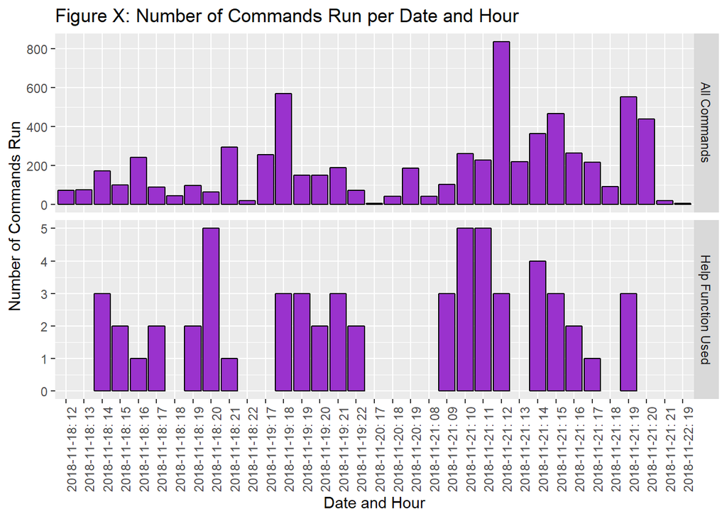

```r
hist.count.all <- history %>% count(hist.date.time) %>% mutate(label='All Commands')
hist.help <- history[which(grepl('\\?', history$hist.text)),] %>% count(hist.date.time) %>% mutate(label='Help Function Used')

ggplot(data=rbind(hist.help, hist.count.all), aes(x=hist.date.time, y=n)) + facet_grid(rows=vars(label), scale = 'free_y') + geom_histogram(stat = 'identity', fill='darkorchid3', colour='black') + theme(axis.text.x = element_text(angle = 90, hjust = 1)) + labs(x = 'Date and Hour', y = 'Number of Commands Run', title='Figure X: Number of Commands Run per Date and Hour')
```

I can see from the graph that I tended to work in large chunks, not taking many breaks. This isn’t ideal for concentration, but as I have other commitments, it’s the only way I can fit in the work.

## 5.2 Personal Reflection

I decided to approach the project by attempting each problem until I got stuck and then moving on to the next one if I was stuck for more than 20 minutes or so, and then going back to the start to finish the problems to the required standard. I’ve learned from previous experience that it’s easier for me to work on improving a question rather than starting something from scratch. By looking at each question in some detail at the start, is also allows ideas to perculate, so when you come back to it later, you might ahve solved the problem or have a new perspective.

It’s also easy to get stuck down a rabbit hole of trying to solve a particular technical problem but then when you looka t it with a fresh mind, you realised that problem didn’t need to be solved at all for the question.

Got stuck down a rabbit hole of joining together dataframes in task 3 and got stuck. Came back to it another day and reread the question and realised I was making it overly complicated.

I sometimes found it hard to figure out whether there was a small issue with my code and I was almost there, or if I was completely wrong: loading bike JSON.

As some of the questions were of the type ‘find the most interesting information’, I decided to first so something relatively basic and straightforward and then come back to it at a later date and improve it if I had time. This would also hopefully give me time to come up with a better idea.

BEcause we have a test coming up where we won’t have internet access, I’ve started using the built in R help function instead of googling the same information, whichi I think it a better habit to get into as you get to understand the inner workings of the function instead of letting someone else intrepret it for you.

[1] https://www.irishexaminer.com/ireland/fivefold-increase-in-online-shopping-since-2007-469059.html (original Euromonitor International report not freely available online)

[2] https://www.cso.ie/px/pxeirestat/Database/eirestat/Overseas%20Travel/Overseas%20Travel_statbank.asp?SP=Overseas%20Travel&Planguage=0y (report TMA14: Overseas Trips to and from Ireland by Trips and Year)

[1] https://developers.google.com/transit/gtfs/reference/